# `SpatialData`

## 1.3 Transformations

To facilitate .zattrs handling, we provide a set of functions to access and modify its contents. Specifically,

- `axes` to access a given element’s dimension names and types
- `CTdata/name/type` to access coordinate transformation components
- `rmv/addCT` to remove, add, or append coordinate transformations

```r
z <- meta(label(x))
axes(z)
```

```
##   name  type
## 1    y space
## 2    x space
```

```r
CTdata(z)
```

```
##     input.axes input.name  output.axes output.name        type scale
## 1 c("y", "....         yx c("y", "....      global    identity
## 2 c("y", "....         yx c("y", "....       scale       scale  3, 2
## 3 c("y", "....         yx c("y", ".... translation translation
## 4 c("y", "....         yx c("x", "....      affine      affine
## 5 c("y", "....         yx c("y", "....    sequence    sequence
##   translation       affine transformations
## 1
## 2
## 3     -50, 10
## 4             20, 50, ....
## 5                             list(axe....
```

```r
CTname(rmvCT(z, "scale"))
```

```
## [1] "global"      "translation" "affine"      "sequence"
```

```r
CTname(addCT(z,
    name="D'Artagnan",
    type="scale",
    data=c(19, 94)))
```

```
## [1] "global"      "scale"       "translation" "affine"      "sequence"
## [6] "D'Artagnan"
```

`Zattrs` specify an explicit relationship between elements and coordinate systems. We can represent these are a graph as follows:

```r
(g <- CTgraph(x))
```

```
## A graphAM graph with directed edges
## Number of Nodes = 14
## Number of Edges = 13
```

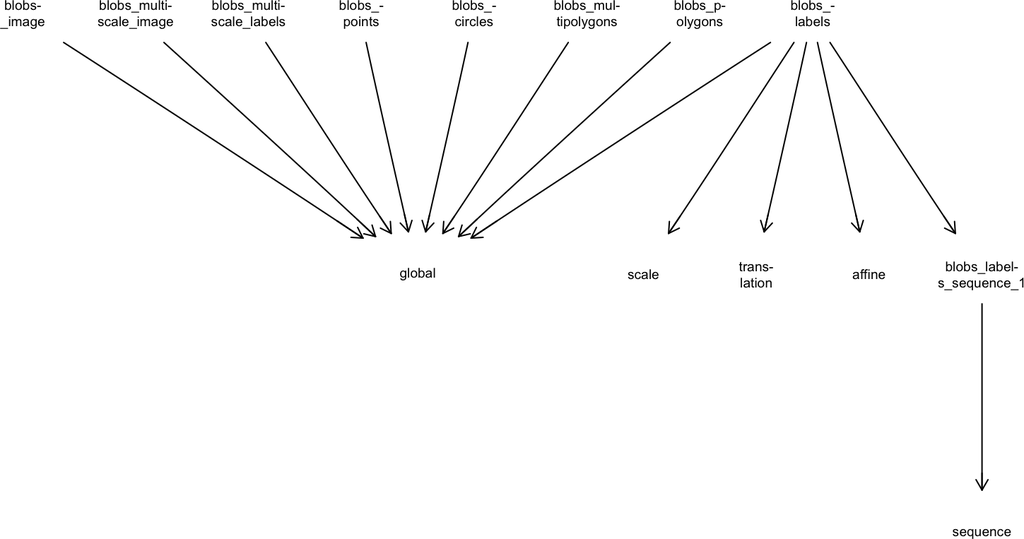

```r
plotCoordGraph(g)
```

The above representation greatly facilitates queries of the transformation(s) required to spatially align elements. `blobs_labels`, for example, requires a sequential transformation (scaling and translation) for the `sequence` space:

```r
# the following are equivalent
i <- "blobs_labels"
j <- "sequence"
y <- label(x, i)
CTpath(x, i, j)
invisible(CTpath(y, j))
```

```
## [[1]]
## [[1]]$data
## [1] 3 2
##
## [[1]]$type
## [1] "scale"
##
##
## [[2]]
## [[2]]$data
## [1] -50  10
##
## [[2]]$type
## [1] "translation"
```

# 2 Datasets

Data from a variety of technologies has been made available as `SpatialData` .zarr stores [here](https://spatialdata.scverse.org/en/latest/tutorials/notebooks/datasets/README.html). These, in turn, have been deposited in Bioconductor’s NSF Open Storage Network bucket, and can be retrieved with caching support using *BiocFileCache*.

We can interrogate the bucket for available (zipped) .zarr archives:

```r
available_spd_zarr_zips()
```

```
## [1] "mcmicro_io.zip"
## [2] "merfish.zarr.zip"
## [3] "mibitof.zip"
## [4] "steinbock_io.zip"
## [5] "visium_associated_xenium_io_aligned.zip"
## [6] "visium_hd_3.0.0_io.zip"
```

Any of the above can be retrieved (once) into some location, and read into R; for example:

```r
dir.create(td <- tempfile())
pa <- unzip_spd_demo(
    zipname="merfish.zarr.zip",
    dest=td, source="biocOSN")
(x <- readSpatialData(pa))
```

```
## class: SpatialData
## - images(1):
##   - rasterized (1,522,575)
## - labels(0):
## - points(1):
##   - single_molecule (3714642)
## - shapes(2):
##   - anatomical (6,polygon)
##   - cells (2389,circle)
## - tables(1):
##   - table (268,2389)
## coordinate systems:
## - global(4): rasterized anatomical cells single_molecule
```